# Bellabeat Analysis

Franco Nicolay

2025-10-15

# **Case Study: Bellabeat App**

## **Phase 1: Ask**

### **1.1 Business Task**

Analyze Fitbit device usage data to identify user behavior patterns and apply these insights to optimize the marketing strategy for **Bellabeat App**.

### **1.2 Key Business Questions**

1. What are the main trends in smart device usage?
2. How can these trends be applied to Bellabeat customers?
3. How can these trends influence Bellabeat’s marketing strategy?

### **1.3 Key Stakeholders**

- **Urška Sršen**: Co-founder and Chief Creative Officer
- **Sando Mur**: Co-founder and Mathematician
- **Marketing Analytics Team**: Marketing decision-makers

## **Phase 2: Prepare**

### **2.1 Data Sources**

- **Dataset**: FitBit Fitness Tracker Data (Kaggle)
- **Main file**: `dailyActivity_merged.csv`
- **Period**: Data from 33 users over approximately 31 days
- **License**: CCO Public Domain

### **2.2 Dataset Characteristics**

The dataset contains daily activity metrics from Fitbit users including steps, calories, activity minutes, and sedentary time.

```
## ### Dataset Summary
```

```
## • Number of unique users: 33
```

```
## • Data period: From 4/12/2016 to 5/9/2016
```

```
## • Total observations: 940 daily records
```

```
## • Key metrics tracked: Steps, Calories, Activity Levels, Sedentary Time
```

### **2.3 Data Quality Assessment (ROCCC)**

- **Reliable**: ✓ Real user data
- **Original**: ✓ Primary source from Fitbit devices
- **Comprehensive**: ⚠ Only 33 users, small sample
- **Current**: ✓ Recent data (2016)
- **Cited**: ✓ Clearly attributed source

## **Phase 3: Process**

### **3.1 Data Cleaning and Transformation**

```
## Clean records: 863
```

```
## Unique users: 33
```

### **3.2 Data Integrity Validation**

All data was checked for null values and inconsistencies. No significant data quality issues were found in the key metrics used for analysis.

```
## ### Data Quality Assessment
```

```
## ✅ No missing values detected - Data quality: EXCELLENT
```

```
## • Total valid records: 863
```

```
## • Unique users: 33
```

```
## • Data completeness: 100% (no missing values)
```

## **Phase 4: Analyze**

### **4.1 Exploratory Analysis**

Key Activity Metrics

| AvgDailySteps | AvgCalories | AvgActiveMinutes | AvgSedentaryMinutes | ActiveUsersRatio |
| --- | --- | --- | --- | --- |
| 8319.39 | 2361.3 | 247.81 | 955.75 | 35.11 |

### **4.2 Activity Patterns by Day of Week**

[figure not shown]

### **4.3 Relationship Between Steps and Calories**

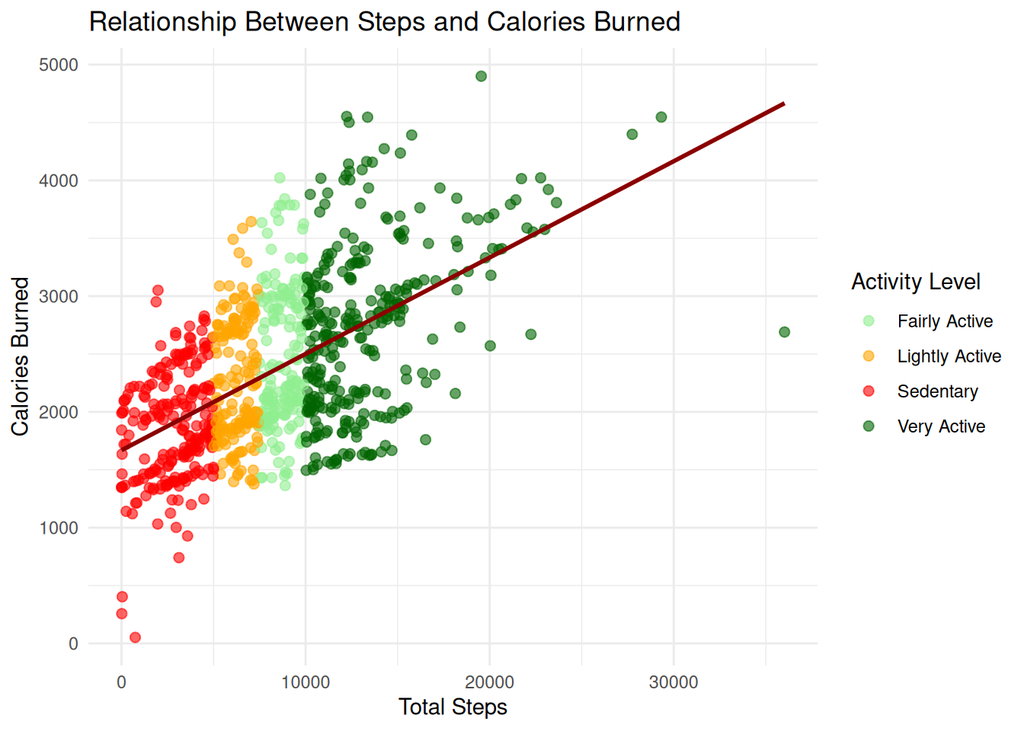

### **4.4 Activity Levels Analysis**

Activity Level Distribution

| ActivityLevel | Count | Percentage | AvgCalories | AvgSedentaryHours |
| --- | --- | --- | --- | --- |
| Fairly Active | 163 | 18.89 | 2461.07 | 15.37 |
| Lightly Active | 171 | 19.81 | 2254.21 | 16.47 |
| Sedentary | 226 | 26.19 | 1857.83 | 17.42 |
| Very Active | 303 | 35.11 | 2743.58 | 14.81 |

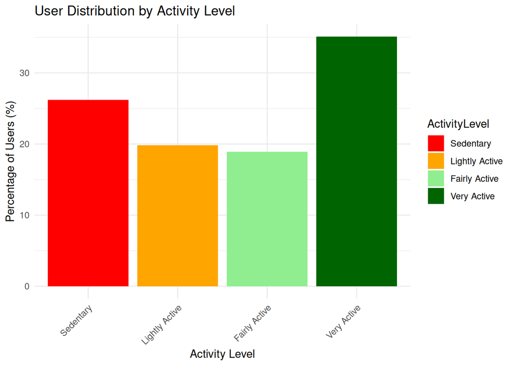

Comparison: Weekdays vs Weekend

[output not shown]

[figure not shown]

## **Phase 5: Share**

### **5.1 Key Findings and Visualizations**

[figure not shown]

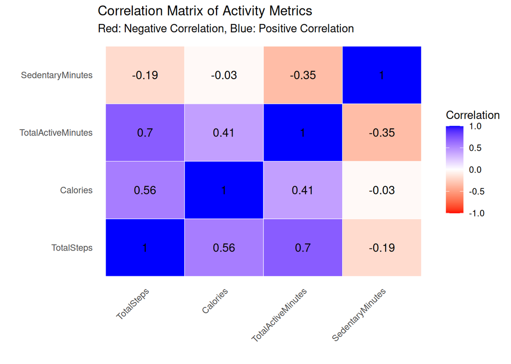

## **Phase 6: Act**

### **Recommendations for Bellabeat App**

#### **Educational Content**

**Strategy**: Develop content that educates about the benefits of different activity types  
**Actions**:  
• Short videos on how to incorporate more light activity into daily routines  
• Monthly challenges focused on gradual progression  
• Content addressing common excuses for inactivity  
• Success stories from users with similar profiles

#### **Personalized Activity Planning**

**Strategy**: Use data patterns to create customized weekly activity plans  
**Actions**:  
• Sunday planning sessions to set goals for the week ahead  
• Adjustable goals based on individual historical performance  
• Flexible scheduling around each user’s most active days  
• Progress tracking with personalized feedback

### **Tracking Metrics**

1. **Daily engagement rate**: Percentage of users who open the app daily
2. **Weekly consistency**: Active days per user per week
3. **Level progression**: Movement between activity categories
4. **Goal achievement rate**: Percentage of users meeting daily step goals
5. **Weekend engagement**: Comparison of weekend vs weekday usage

### **Implementation Plan**

#### **Success Metrics**

- 15% increase in daily active users
- 20% improvement in weekly consistency
- 25% more users achieving 10,000 steps daily
- 10% increase in weekend engagement

#### **Next Steps**

1. Validate findings with larger dataset and broader user demographics
2. Conduct A/B testing with the proposed recommendations
3. Segment analysis by specific demographic groups (age, gender, location)
4. Develop prototype features for user testing
5. Create detailed implementation roadmap with resource allocation

**Note**: This analysis is based on limited data (33 users). It is recommended to validate conclusions with larger samples and conduct user research before implementing significant business strategy changes. The recommendations should be tested in controlled environments to measure actual impact on user behavior and business metrics.